# Make Matchups

B Steele, Colorado State University, ROSSyndicate

last updated Sept 15, 2026

This code creates matchups between the filtered AquaMatch SDD and siteSR files (from `01_filter_AquaMatch_Data.Rmd`) using a generous 5-day window. Both inputs are already scoped to the HUC4 basins that make up this project’s 6-state regional AOI (that scoping happens in `01_filter_AquaMatch_Data.Rmd`, before the expensive per-site filtering there runs), so the “Subset to the regional AOI” section below is a labeling/sanity-check step rather than an additional filter.

## Setup

```r
# load libraries
library(AquaMatchr) # if install needed: remotes::install_github(repo = "AquaSat/AquaMatchr")
library(data.table)
library(arrow)
library(sf)
library(tmap)
library(tigris)
library(tidyverse)
library(climateR) # gap-period rain check's own gridMET fetch
library(parallel)

aquamatch_raw_data_dir <- "regional_clarity/aquamatch_files/downloads"
filtered_aquamatch_dir <- "regional_clarity/aquamatch_files"

# outputs from 01_filter_AquaMatch_Data.Rmd
sdd_filtered_path <- file.path(filtered_aquamatch_dir, "sdd_quality_filter.parquet")
siteSR_regional_filtered_path <- file.path(filtered_aquamatch_dir, "siteSR_DSWE1_regional_band_filtered.parquet")
sr_sites <- file.path(aquamatch_raw_data_dir, "siteSR_collated_WQP_NWIS_sites_with_NHD_info_2025-06-04.csv")
```

## Make matches with the filtered data

Use the regionally band-filtered siteSR data (rather than the full nationwide `unified_data`) as the input to matching, so a site flagged in script 01 simply isn’t a match candidate.

`match_siteSR_to_WQP()` only accepts `.csv`/`.feather` for its WQP input and hard-codes `.feather` for its siteSR input - parquet isn’t a supported input format for this AquaMatchr function. Our filtered caches from script 01 are parquet (see that script’s note on preferring parquet everywhere it isn’t required to be otherwise), so we write throwaway feather copies just for this call and delete them immediately after.

```r
out_file <- file.path(filtered_aquamatch_dir, "sdd_regional_siteSR_matchups_5d.parquet")

if (file.exists(out_file)) {
  sdd_match <- read_parquet(out_file)
} else {
  # throwaway feather copies, required by match_siteSR_to_WQP()'s input format
  sdd_filtered_feather <- tempfile(fileext = ".feather")
  siteSR_regional_filtered_feather <- tempfile(fileext = ".feather")
  # is_inlier == FALSE is a RANSAC-flagged SDD outlier (see
  # 01_filter_AquaMatch_Data.Rmd); NA (RANSAC never resolved, e.g. too few
  # points at that site) is kept rather than assumed guilty
  write_feather(read_parquet(sdd_filtered_path) %>%
                  filter(is_inlier | is.na(is_inlier)),
                sdd_filtered_feather)
  write_feather(read_parquet(siteSR_regional_filtered_path), siteSR_regional_filtered_feather)

  # Run the matchups with a 5-day window
  match_siteSR_to_WQP(
    wqp_path = sdd_filtered_feather,
    siteSR_path = siteSR_regional_filtered_feather,
    site_list_path = sr_sites,
    save_location = out_file,
    time_window = "5 days"
  )

  file.remove(sdd_filtered_feather, siteSR_regional_filtered_feather)

  sdd_match <- read_parquet(out_file)
}
```

Let’s confirm we’re only matching Lake data for our purposes and that the Great Lakes were already excluded - this is a sanity check on the site filters already applied upstream, not an additional filter.

```r
lake_sdd <- sdd_match %>%
  filter(
    # select for lake/reservoir only
    grepl("Lake|Reservoir", MonitoringLocationTypeName),
    # remove the great lakes for this matching process
    !grepl("Great", MonitoringLocationTypeName)
  )

# check to see if these are the same
nrow(lake_sdd) == nrow(sdd_match)
```

```
## [1] TRUE
```

## Summary Figures

```r
sites <- read_csv(sr_sites, show_col_types = FALSE)
```

```r
sites_w_matches <- sites %>%
  filter(siteSR_id %in% unique(sdd_match$siteSR_id)) %>%
  st_as_sf(coords = c("WGS84_Longitude", "WGS84_Latitude"), crs = "EPSG:4326")

# let's drop the ones that are outside the CONUS for the purposes of this
conus <- suppressMessages(states(progress_bar = FALSE)) %>%
  filter(!grepl("AK|AS|MP|VI|HI|PR|GU", STUSPS))

lake_locs_CONUS <- sites_w_matches %>%
  st_transform(., st_crs(conus)) %>%
  .[conus,] %>%
  st_transform(., st_crs(sites_w_matches))
```

And plot

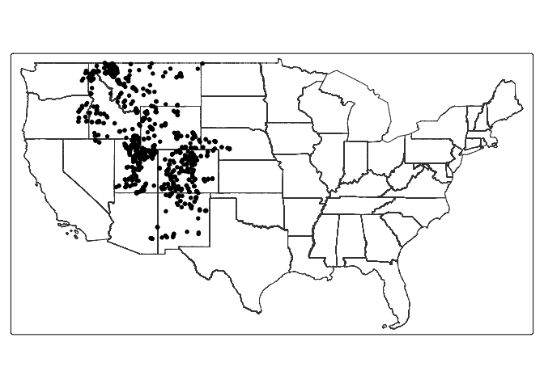

```r
tm_shape(conus) +
  tm_borders() +
  tm_shape(lake_locs_CONUS) +
  tm_dots()
```

Make some summary tables

```r
# summarize by number of matches per site
five_day_summary <- sdd_match %>%
  summarize(n = n(),
            .by = siteSR_id)

# add in spatial data
lake_locs_with_matches <- lake_locs_CONUS %>%
  filter(siteSR_id %in% unique(sdd_match$siteSR_id)) %>%
  left_join(., five_day_summary)
```

Plot locations colored by number of matches

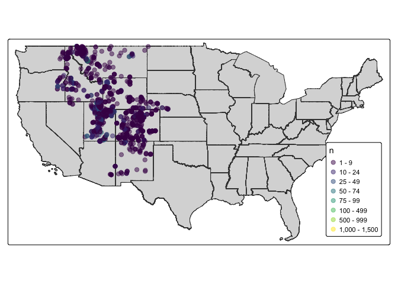

```r
# plot all missions
tm_shape(conus) +
  tm_polygons() +
  tm_shape(lake_locs_with_matches, bbox = conus) +
  tm_dots("n",
          fill.scale = tm_scale(breaks = c(1, 10, 25, 50, 75, 100,
                                           500, 1000, 1500),
                                values = "viridis"),
          size = 0.5,
          fill_alpha = 0.5) +
  tm_layout(legend.position = tm_pos_in("right", "bottom"),
            legend.bg.color = "white",
            legend.frame = TRUE)
```

And also by number of matches per mission

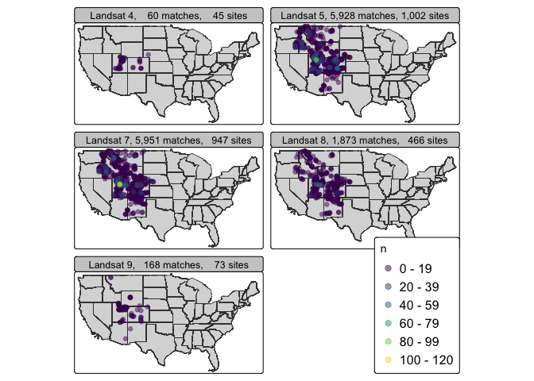

```r
# and per site per mission
five_day_summary_sensor <- sdd_match %>%
  summarize(n = n(),
            .by = c(siteSR_id, mission))

# add spatial data and label info
lake_locs_by_mission <- lake_locs_CONUS %>%
  select(siteSR_id, geometry) %>%
  right_join(five_day_summary_sensor, by = "siteSR_id") %>%
  mutate(mission = factor(mission,
                          levels = c("LT04", "LT05", "LE07", "LC08", "LC09"),
                          labels = c("Landsat 4", "Landsat 5", "Landsat 7", "Landsat 8", "Landsat 9")))%>%
  arrange(n)

# Compute totals per mission before faceting
mission_stats <- lake_locs_by_mission %>%
  st_drop_geometry() %>%
  summarize(total_matches = sum(n),
            total_sites = n_distinct(siteSR_id),
            .by = mission)

# and prep for viz
lake_locs_by_mission <- lake_locs_by_mission %>%
  left_join(mission_stats, by = "mission") %>%
  mutate(mission_label = paste0(mission, ", ",
                                format(total_matches, big.mark = ","), " matches, ",
                                format(total_sites, big.mark = ","), " sites")) %>%
  arrange(n)

# plot!
tm_shape(conus) +
  tm_polygons() +
  tm_shape(lake_locs_by_mission, bbox = conus) +
  tm_dots("n",
          fill.scale = tm_scale(values = "viridis"),
          fill.legend = tm_legend(position = tm_pos_on_top(pos.h = "right", pos.v = "bottom"),
                                  bg.color = "white",
                                  frame = TRUE, text.size = 1),
          size = 0.5,
          fill_alpha = 0.5) +
  tm_facets_wrap(by = "mission_label", ncol = 2, nrow = 3)
```

## Subset to the regional AOI

`siteSR` was already scoped to our 6-state region’s HUC4 footprint upstream in `01_filter_AquaMatch_Data.Rmd` (see that script’s “Regional AOI” section) - there’s no regional-context-dependent processing between that scoping and here, so every match in `sdd_match` should already fall inside it. We read back the HUC4/state boundaries 01 already computed and wrote out, rather than re-running the HUC4 download/overlap calculation, and use them here only to label each site with its HUC4 (for the summaries below) and as a sanity check on the upstream scoping.

```r
# standardize the geometry column name to "geometry" - the OpenFileGDB
# driver renames it to "SHAPE" on write, regardless of the name it had
# in 01_filter_AquaMatch_Data.Rmd before export
standardize_geom_col <- function(x) {
  geom_col <- attr(x, "sf_column")
  if (geom_col != "geometry") {
    names(x)[names(x) == geom_col] <- "geometry"
    st_geometry(x) <- "geometry"
  }
  x
}

HUC4_filtered <- st_read(file.path(filtered_aquamatch_dir, "huc4_filtered.gdb"),
                         layer = "huc4_filtered", quiet = TRUE) %>%
  standardize_geom_col()
states <- st_read(file.path(filtered_aquamatch_dir, "states.gdb"),
                  layer = "states", quiet = TRUE) %>%
  standardize_geom_col()
```

```r
# add huc info - this is a labeling join (and a sanity check on the
# upstream regional scoping), not an additional filter: `left = FALSE` drops
# any matched site that somehow falls outside every regional HUC4, which
# shouldn't happen given the upstream scoping
regional_sites <- sites_w_matches %>%
  st_transform(st_crs(HUC4_filtered)) %>%
  st_join(HUC4_filtered %>% select(huc4), left = FALSE)

cat(n_distinct(regional_sites$siteSR_id), "of",
    n_distinct(sites_w_matches$siteSR_id),
    "matched sites fall within the regional HUC4 footprint",
    "(should be all of them, since siteSR was already scoped to this",
    "footprint upstream in 01_filter_AquaMatch_Data.Rmd)\n")
```

```
## 1462 of 1462 matched sites fall within the regional HUC4 footprint (should be all of them, since siteSR was already scoped to this footprint upstream in 01_filter_AquaMatch_Data.Rmd)
```

```r
# add sdd info back, carrying along each site's HUC4 label
regional_sdd <- sdd_match %>%
  filter(siteSR_id %in% regional_sites$siteSR_id) %>%
  left_join(
    regional_sites %>%
      st_drop_geometry() %>%
      select(siteSR_id, HUC4 = huc4) %>%
      # guard against a site sitting exactly on a shared HUC4 boundary,
      # which could otherwise match more than one polygon in the spatial join
      distinct(siteSR_id, .keep_all = TRUE),
    by = "siteSR_id"
  )
```

## Screen for heavy rain events between image and field dates

For each candidate match (every SDD/siteSR pair within the 5-day window, before any closest-in-time selection), was there a heavy single-day rain event between the image date and the field (SDD) date - in either order? If so, the reflectance and the target describe genuinely different water states, and the matchup shouldn’t be trusted regardless of which one came first. NOAA/EPA’s “heavy precipitation day” cut of 1 inch (25.4 mm) in 24 hours, peak single-day intensity within the gap (not cumulative gap-total, which would conflate a genuine storm with a longer gap simply having more days to accumulate ordinary rain).

This screens **candidates**, before the closest-in-time selection below, not after: filtering the already-deduped closest-match dataset would drop an observation outright whenever its single nearest candidate image happened to be rain-contaminated, even when a perfectly good, only slightly-further-away, uncontaminated image was also available in the window. Screening first lets closest-in-time selection fall back to that next-best candidate instead.

Needs raw daily gridMET precipitation for every candidate site, over each site’s full candidate-date range - a broader, coarser need than `pull_weather_summaries.Rmd`’s antecedent-window feature fetch (which only needs narrow 1-30 day windows ending at each *already-matched* row’s date), so this is its own fetch rather than a reuse of that cache. Also breaks a real circularity: `pull_weather_summaries.Rmd` fetches weather for the *output* of this script, so it isn’t available yet at this point in the pipeline.

```r
HEAVY_RAIN_MM <- 25.4  # NOAA/EPA "heavy precipitation day" threshold (1 inch/24hr)

regional_sdd <- regional_sdd %>%
  mutate(date = as.Date(date),
         field_date = as.Date(harmonized_local_time),
         gap_start = pmin(date, field_date),
         gap_end = pmax(date, field_date))

rain_check_weather_raw_path <- file.path(filtered_aquamatch_dir, "match_gap_precip_raw.feather")

if (file.exists(rain_check_weather_raw_path)) {
  gap_precip_raw <- read_feather(rain_check_weather_raw_path)
} else {
  site_ranges <- regional_sdd %>%
    left_join(sites %>% select(siteSR_id, WGS84_Latitude, WGS84_Longitude), by = "siteSR_id") %>%
    summarize(min_date = min(gap_start) - 1, max_date = max(gap_end),
              lat = first(WGS84_Latitude), lon = first(WGS84_Longitude), .by = siteSR_id)
  cat(sprintf("[%s] fetching gridMET precip for %s sites\n", format(Sys.time(), "%H:%M:%S"), nrow(site_ranges)))

  fetch_one <- function(i, site_ranges) {
    row <- site_ranges[i, ]
    fetch <- function() {
      pt <- sf::st_as_sf(data.frame(lon = row$lon, lat = row$lat), coords = c("lon", "lat"), crs = 4326)
      res <- getGridMET(AOI = pt, varname = "pr",
                        startDate = as.character(row$min_date), endDate = as.character(row$max_date))
      res$siteSR_id <- row$siteSR_id
      res
    }
    tryCatch(fetch(), error = function(e) {
      Sys.sleep(2)
      tryCatch(fetch(), error = function(e2) data.frame(siteSR_id = row$siteSR_id, error = conditionMessage(e2)))
    })
  }

  t0 <- Sys.time()
  cl <- makeCluster(8, type = "PSOCK")
  clusterEvalQ(cl, { suppressMessages(library(climateR)); suppressMessages(library(sf)) })
  clusterExport(cl, c("site_ranges", "fetch_one"))
  results <- parLapply(cl, seq_len(nrow(site_ranges)), fetch_one, site_ranges = site_ranges)
  stopCluster(cl)
  cat(sprintf("[%s] fetch took %.1f min\n", format(Sys.time(), "%H:%M:%S"),
              as.numeric(difftime(Sys.time(), t0, units = "mins"))))

  ok <- Filter(function(x) !"error" %in% names(x), results)
  failed <- Filter(function(x) "error" %in% names(x), results)
  cat(sprintf("[%s] succeeded: %s sites, failed: %s sites\n", format(Sys.time(), "%H:%M:%S"), length(ok), length(failed)))
  if (length(failed) > 0) {
    write_csv(bind_rows(failed), file.path(filtered_aquamatch_dir, "match_gap_precip_fetch_failures.csv"))
  }

  gap_precip_raw <- bind_rows(ok) %>% mutate(date = as.Date(date))
  write_feather(gap_precip_raw, rain_check_weather_raw_path)
}
```

```
## [22:48:36] fetching gridMET precip for 1462 sites
## [22:55:11] fetch took 6.6 min
## [22:55:11] succeeded: 1462 sites, failed: 0 sites
```

```r
# peak single-day precip strictly BETWEEN gap_start and gap_end (exclusive of
# gap_start itself, the "day of" whichever event is earlier) - a data.table
# non-equi (interval) join, not a row-by-row filter (the latter would be an
# O(n_candidates x n_weather_rows) scan)
regional_sdd <- regional_sdd %>% mutate(cand_id = row_number())
candidates_dt <- as.data.table(regional_sdd %>%
                                 select(cand_id, siteSR_id, gap_start, gap_end))
wx_dt <- as.data.table(gap_precip_raw %>% select(siteSR_id, date, pr))
setkey(wx_dt, siteSR_id, date)

joined <- wx_dt[candidates_dt, on = .(siteSR_id, date > gap_start, date <= gap_end),
                nomatch = NA, allow.cartesian = TRUE]
gap_max <- joined[, .(gap_max_precip_mm = max(pr, na.rm = TRUE)), by = cand_id]
gap_max[!is.finite(gap_max_precip_mm), gap_max_precip_mm := 0]

regional_sdd <- regional_sdd %>%
  left_join(as.data.frame(gap_max), by = "cand_id") %>%
  mutate(gap_max_precip_mm = coalesce(gap_max_precip_mm, 0))

n_flagged <- sum(regional_sdd$gap_max_precip_mm >= HEAVY_RAIN_MM)
cat(sprintf("[%s] %s / %s candidate matches flagged for a heavy single-day rain event (>= %.1f mm) between image and field dates - excluded before closest-match selection\n",
            format(Sys.time(), "%H:%M:%S"), n_flagged, nrow(regional_sdd), HEAVY_RAIN_MM))
```

```
## [22:55:11] 26 / 13980 candidate matches flagged for a heavy single-day rain event (>= 25.4 mm) between image and field dates - excluded before closest-match selection
```

```r
regional_sdd <- regional_sdd %>%
  filter(gap_max_precip_mm < HEAVY_RAIN_MM) %>%
  select(-field_date, -gap_start, -gap_end, -cand_id, -gap_max_precip_mm)
```

## QA the data

Make sure we’re using the observation closest in time to the measurement. This assures we’re not using multiple satellites for the same data point in our training dataset. We will also export those that are not included as a possible additional test set.

```r
# grab the observation closes in date to a satellite flyover, from the
# rain-screened candidate pool built above
reg_sdd_closest <- regional_sdd %>%
  arrange(abs(time_diff), mission) %>%
  slice(1, .by = c("subgroup_id"))

# let's also do an anti-join here of the other observations so that we have an
# additional validation dataset to play with.
reg_sdd_additional <- anti_join(regional_sdd, reg_sdd_closest)
```

[output not shown]

```r
write_parquet(reg_sdd_additional,
              file.path(filtered_aquamatch_dir, "regional_sdd_not_closest.parquet"))
```

## Visualize data

Let’s look at some longer records to do a sanity check to make sure that all the filters worked correctly.

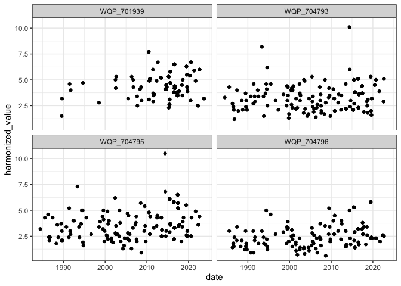

```r
# summarize by site for plotting
regional_site_summary <- reg_sdd_closest %>%
  st_as_sf(coords = c("lon", "lat"),
           crs = "EPSG:4326") %>%
  summarize(n = n(), .by = c(siteSR_id, geometry)) %>%
  arrange(n)

# look at some of the records with a lot of data
regional_long_record <- regional_site_summary %>%
  filter(n > 100) %>%
  left_join(., reg_sdd_closest)
ggplot(regional_long_record, aes(x = date, y = harmonized_value)) +
  geom_point() +
  facet_wrap(siteSR_id ~ .) +
  theme_bw()
```

Look at data spatially by site

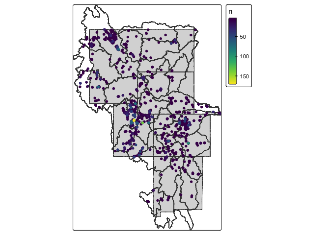

```r
tm_shape(HUC4_filtered) +
  tm_shape(states %>%
             st_transform(st_crs(HUC4_filtered))) +
  tm_polygons() +
  tm_shape(HUC4_filtered) +
  tm_polygons(fill_alpha = 0) +
  tm_shape(regional_site_summary %>%
             st_transform(st_crs(HUC4_filtered))) +
  tm_dots("n",
          fill.scale = tm_scale_continuous(values = "viridis"))
```

And summarize by HUC4

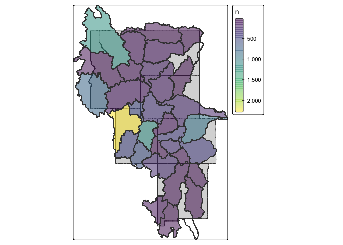

```r
regional_huc_summary <- reg_sdd_closest %>%
  st_as_sf(coords = c("lon", "lat"),
           crs = "EPSG:4326") %>%
  st_transform(., st_crs(HUC4_filtered)) %>%
  st_join(HUC4_filtered, .) %>%
  summarize(n = sum(!is.na(siteSR_id)), .by = c(huc4, geometry))


tm_shape(HUC4_filtered) +
  tm_shape(states %>%
             st_transform(st_crs(HUC4_filtered))) +
  tm_polygons() +
  tm_shape(HUC4_filtered) +
  tm_polygons(fill_alpha = 0) +
  # drop 0-count HUC4s so they're left uncolored (outline only) instead of
  # taking the low end of the viridis scale
  tm_shape(regional_huc_summary %>% filter(n > 0)) +
  tm_polygons("n",
              fill.scale = tm_scale_continuous(values = "viridis"),
              fill_alpha = 0.5)
```

## Data Retention Summary

```r
row_log <- read_csv(file.path(filtered_aquamatch_dir, "row_loss_log_01.csv"),
                    show_col_types = FALSE) %>%
  bind_rows(
    tibble(pipeline = "matched", step = "0_5day_window_match",
           n_rows = nrow(sdd_match), n_sites = n_distinct(sdd_match$siteSR_id)),
    tibble(pipeline = "matched", step = "1_closest_observation_final",
           n_rows = nrow(reg_sdd_closest), n_sites = n_distinct(reg_sdd_closest$siteSR_id))
  )

write_csv(row_log, file.path(filtered_aquamatch_dir, "row_loss_log.csv"))
```

```r
row_log_display <- row_log %>%
  mutate(pipeline = factor(pipeline, levels = c("SDD", "siteSR", "matched"))) %>%
  arrange(pipeline, step) %>%
  group_by(pipeline) %>%
  mutate(step_label = step %>%
           str_remove("^[0-9]+[a-z]?_") %>%
           str_replace_all("_", " ") %>%
           str_to_sentence(),
         pct_of_raw = round(100 * n_rows / first(n_rows), 1),
         pct_of_previous = round(100 * n_rows / lag(n_rows), 1)) %>%
  ungroup() %>%
  select(pipeline, step_label, n_rows, n_sites, pct_of_previous, pct_of_raw)

knitr::kable(row_log_display,
             col.names = c("Pipeline", "Step", "Total Rows", "Total Sites",
                           "% of previous step retained", "% of pipeline's first step retained"),
             format.args = list(big.mark = ",")) %>%
  kableExtra::kable_styling(full_width = FALSE) %>%
  # merge consecutive same-pipeline cells into one spanning cell, so the
  # table reads as three grouped blocks (SDD/siteSR/matched) rather than a
  # flat list repeating the pipeline name on every row
  kableExtra::collapse_rows(columns = 1, valign = "top")
```

| Pipeline | Step | Total Rows | Total Sites | % of previous step retained | % of pipeline’s first step retained |
| --- | --- | --- | --- | --- | --- |
| SDD | Raw nationwide | 2,739,358 | NA | NA | 100.0 |
|  | Quality tier flag filters | 1,654,029 | 67,369 | 60.4 | 60.4 |
|  | Regional huc4 restriction | 35,374 | 2,783 | 2.1 | 1.3 |
|  | Ransac inliers for matching | 35,183 | 2,783 | 99.5 | 1.3 |
| siteSR | Raw nationwide | 167,472,586 | 342,704 | NA | 100.0 |
|  | Geometry and huc4 scoped | 7,381,846 | 10,369 | 4.4 | 4.4 |
|  | Metadata scene qa | 4,510,842 | 9,961 | 61.1 | 2.7 |
|  | Band ransac filter final | 4,318,743 | 9,961 | 95.7 | 2.6 |
| matched | 5day window match | 13,980 | 1,462 | NA | 100.0 |
|  | Closest observation final | 11,143 | 1,462 | 79.7 | 79.7 |

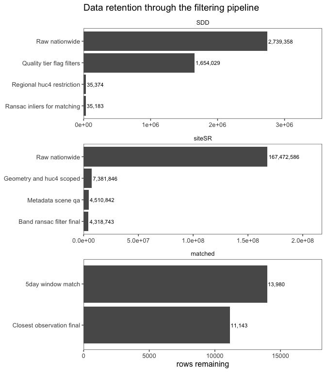

```r
row_log_display %>%
  # fct_inorder() alone would put the first (largest) step at the bottom
  # after coord_flip() - reverse it so bars read largest-to-smallest top-down
  mutate(step_label = fct_rev(fct_inorder(step_label))) %>%
  ggplot(aes(x = step_label, y = n_rows)) +
  geom_col() +
  geom_text(aes(label = scales::comma(n_rows)), hjust = -0.05, size = 3) +
  facet_wrap(~ pipeline, scales = "free", ncol = 1) +
  coord_flip() +
  scale_y_continuous(expand = expansion(mult = c(0, 0.3))) +
  labs(x = NULL, y = "rows remaining",
       title = "Data retention through the filtering pipeline") +
  ggthemes::theme_few() +
  theme(legend.position = "none")
```

## Export data

```r
write_parquet(reg_sdd_closest,
              file.path(filtered_aquamatch_dir,
                        "filtered_regional_sdd.parquet"))
```